# Methods

## Study site

This study was done in a neotropical lowland rainforest on the Osa Peninsula at the Greg Gund Conservation Center (approx. 8.3778176, -83.2935426) near the Piro Biological Station run by Osa Conservation. (See *Taylor et al. (2015)* for a broader ecosystem description of the region.) The study site was a regrowing 20 ha timber plantation of *Bombacompsis quinata* abandoned in ~1990 after the dry-adapted species from the Guanacaste region *(Pérez Cordero and Kanninen 2002; Hulshof and Powers 2020)* grew poorly in very wet conditions. This focal secondary forest area was roughly triangular, surrounded by primary forest on the two S and NW sides (Fig 1) and a wide service road on the third NE border, with primary forest beyond it. This census was done in 2013 during the rainy season months between June and August.

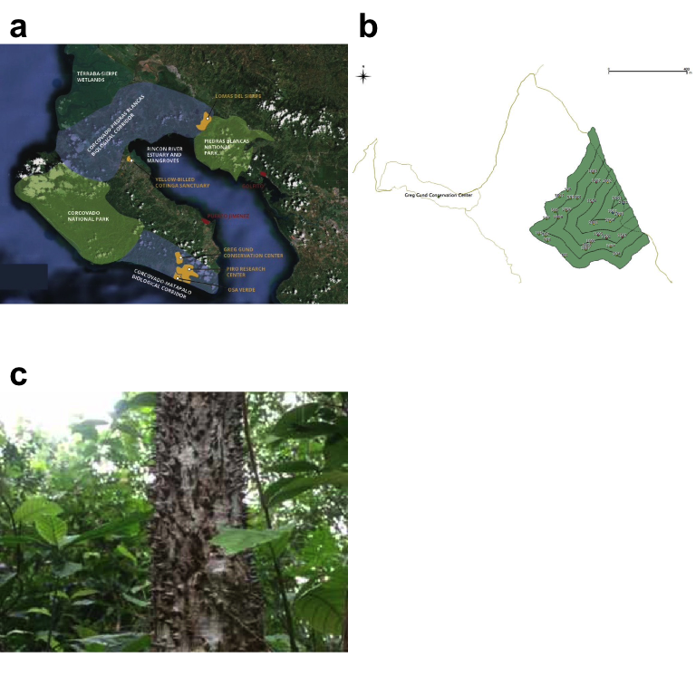

Figure 1: Map of (a) conservation areas and (b) study site of (c) Bombacopsis quinata timber plantation on Osa Peninsula, Costa Rica. Map image data © 2022 Osa Conservation. Photo credit: Nicholas Medina.

## Census design

Edge effects were studied by dividing the secondary forest area into six 50 m strata spanning 0 - 300 m away from the primary forest edge on the S and NW sides, going inward to the E (Fig 1), using available GIS software (*ArcGIS 10*, esri.com, and *QGIS 2*, qgis.org). Each stratum was randomly filled with a number of 21 x 21 m square census plots oriented N that was proportional to its area–specifically with 11, eight, five, three, two, and one plot(s), respectively, as distance away from primary forest increased. The total area of the 30 census plots equaled ~1 ha or 5% of the total secondary forest stand area, which is comparable to similar studies *(Onyekwelu and Olabiwonnu 2016)*.

## Plot measurements

Light reaching the forest floor was measured at the center of each plot at chest height using a densiometer *(Forestry Suppliers, Inc.)*, as an average of four readings taken facing each cardinal direction.

The slope of the forest floor was measured using a rangefinder *(Bushnell, Forestry Suppliers, Inc)* to measure the distance the diagonal between two plot corners and triangulate the observation angle.

The diameter of all stems >10 cm wide were recorded in each census plot, totaling over 1,000 trees. Following common forestry guidelines, in cases where a tree split into 2 or more stems below breast height, each stem was measured separately; in cases where a stem split only above breast height, it was measured as a single stem. Tree height was recorded by measuring distances to both the crown and the stem at chest height *(~2.7 m)* using a rangefinder *(Bushnell, Forestry Suppliers, Inc.)* and triangulating the missing side length. Taxa were identified with localized knowledge and field guides matching common names to Latin binomials, and trait information was gathered from the literature.

Aboveground biomass (AGB) was estimated per stem using the allometric equation by *Jérôme Chave et al. (2015)*. The equation specifically for wet tropical forests was used, which has performed slightly better compared to both pantropical and previous other models by *J. Chave et al. (2005; Alvarez et al. 2012; Ngomanda et al. 2014)*. The equation version with height was used since height was accessibly measurable and has shown improved local accuracy *(Domke et al. 2012; Khan et al. 2020)*. Wood density (or specific gravity) values when available also improve biomass estimates even more than height *(Van Breugel et al. 2011)*. The equation used was:
$${AGB} = 0.0673 (p D^2 H)^{0.976}$$
with diameter *D* in cm, height *H* in m, and wood density or specific gravity *p* in *g cm<sup>-3</sup>*. DBHs and heights were measured in the field and wood densities were extracted from available literature. Where information was limited, values at the genus level were used and unrepresented taxa were assumed to be *0.58* following World Agroforestry Database guidelines (worldagroforestry.org). Original values found and recorded were later updated to modern values using the pipeline developed in the *BIOMASS* 2.1.8 R software package by *Réjou-Méchain et al. (2017)*, which notably replaced unknown wood density values with plot-level averages instead during stem biomass calculations.

Traits including successional stage and main dispersal mode were matched to species with *Werden et al. (2020)* data, and wood tissue carbon matched to genera with the GLOWCAD database *(Doraisami et al. 2022)* given high alignment at species levels *(Jérôme Chave et al. 2006)*.

## Statistical analyses

For all response variables, data were analyzed using plot or distance strata medians and subject to linear regression with distance to forest edge as the only independent variable, after assumption checks of residual normality with Shapiro-Wilk tests and equal variance with Levene tests, using base R version 4.2.0 (2022-04-22) and *rstatix* 0.7.0 package functions *(R Core Team 2022)*.

Non-linear regressions were run using the function *poly()* in the base R package *stats* 4.2.0, which was only ultimately recorded for stem density and richness variables, based on significance and explained variance over linear models. All trees censused were included in each analysis including unidentified taxa that represented a single group in taxa-specific analyses. Community analysis and ordination was done as a PERMANOVA with the *adonis()* function from the *vegan* 2.6.2 R package *(Dixon 2003)*. Data and code were organized with R packages *here* *(Müller 2020)*, *bookdown* *(Xie 2022)*, and *grateful* *(Rodríguez-Sánchez, Jackson, and Hutchins 2022)*, and internal pipeline *oir* *(Medina 2022a)* are stored at github.com/nmedina17/osa *(Medina 2022b)*.

Alvarez, Esteban, Alvaro Duque, Juan Saldarriaga, Kenneth Cabrera, Gonzalo de las Salas, Ignacio del Valle, Alvaro Lema, Flavio Moreno, Sergio Orrego, and Leonidas Rodríguez. 2012. “Tree Above-Ground Biomass Allometries for Carbon Stocks Estimation in the Natural Forests of Colombia.” *Forest Ecology and Management* 267: 297–308. https://doi.org/10.1016/j.foreco.2011.12.013.

Chave, J., C. Andalo, S. Brown, M. A. Cairns, J. Q. Chambers, D. Eamus, H. Fölster, et al. 2005. “Tree Allometry and Improved Estimation of Carbon Stocks and Balance in Tropical Forests.” *Oecologia* 145 (1): 87–99. https://doi.org/10.1007/s00442-005-0100-x.

Chave, Jérôme, Helene C. Muller-Landau, Timothy R. Baker, Tomás A. Easdale, Hans ter Steege, and Campbell O. Webb. 2006. “REGIONAL AND PHYLOGENETIC VARIATION OF WOOD DENSITY ACROSS 2456 NEOTROPICAL TREE SPECIES.” *Ecological Applications* 16 (6): 2356–67. https://doi.org/10.1890/1051-0761(2006)016[2356:RAPVOW]2.0.CO;2.

Chave, Jérôme, Maxime Réjou-Méchain, Alberto Búrquez, Emmanuel Chidumayo, Matthew S. Colgan, Welington B. C. Delitti, Alvaro Duque, et al. 2015. “Improved Allometric Models to Estimate the Aboveground Biomass of Tropical Trees.” *Global Change Biology* 20 (10): 3177–90. https://doi.org/10.1111/gcb.12629.

Dixon, Philip. 2003. “VEGAN, a Package of R Functions for Community Ecology.” *Journal of Vegetation Science* 14 (6): 927–30. https://doi.org/10.1111/j.1654-1103.2003.tb02228.x.

Domke, Grant M., Christopher W. Woodall, James E. Smith, James A. Westfall, and Ronald E. McRoberts. 2012. “Consequences of Alternative Tree-Level Biomass Estimation Procedures on U.S. Forest Carbon Stock Estimates.” *Forest Ecology and Management* 270: 108–16. https://doi.org/10.1016/j.foreco.2012.01.022.

Doraisami, Mahendra, Rosalyn Kish, Nicholas J. Paroshy, Grant M. Domke, Sean C. Thomas, and Adam R. Martin. 2022. “A Global Database of Woody Tissue Carbon Concentrations.” *Scientific Data* 9 (1): 284. https://doi.org/10.1038/s41597-022-01396-1.

Hulshof, Catherine M., and Jennifer S. Powers. 2020. “Tropical Forest Composition and Function Across Space and Time: Insights from Diverse Gradients in Área de Conservación Guanacaste.” *Biotropica* 52 (6): 1065–75. https://doi.org/10.1111/btp.12689.

Khan, Md Nabiul Islam, Md Rafikul Islam, Atikur Rahman, Md Salim Azad, Abdus Subhan Mollick, Md Kamruzzaman, Md Nazmus Sadath, S. M. Feroz, Md Golam Rakkibu, and Alexander Knohl. 2020. “Allometric Relationships of Stand Level Carbon Stocks to Basal Area, Tree Height and Wood Density of Nine Tree Species in Bangladesh.” *Global Ecology and Conservation* 22. https://doi.org/10.1016/j.gecco.2020.e01025.

Medina, Nicholas. 2022a. *Code for: Automating statistical decision trees for data exploration and analysis revision workflow* (version 0.9.1). https://doi.org/10.5281/zenodo.6800299.

———. 2022b. *Code for: Habitat edges affect tree diversity more than biomass regeneration in a wet neotropical secondary forest* (version 0.9.0). https://doi.org/10.5281/zenodo.6816612.

Müller, Kirill. 2020. *Here: A Simpler Way to Find Your Files*. https://CRAN.R-project.org/package=here.

Ngomanda, Alfred, Nestor Laurier Engone Obiang, Judicaël Lebamba, Quentin Moundounga Mavouroulou, Hugues Gomat, Géraud Sidoine Mankou, Joël Loumeto, et al. 2014. “Site-Specific Versus Pantropical Allometric Equations: Which Option to Estimate the Biomass of a Moist Central African Forest?” *Forest Ecology and Management* 312: 1–9. https://doi.org/10.1016/j.foreco.2013.10.029.

Onyekwelu, Jonathan C., and Adeola A. Olabiwonnu. 2016. “Can Forest Plantations Harbour Biodiversity Similar to Natural Forest Ecosystems over Time?” *International Journal of Biodiversity Science, Ecosystem Services and Management* 12 (1-2): 108–15. https://doi.org/10.1080/21513732.2016.1162199.

Pérez Cordero, Luis Diego, and Markku Kanninen. 2002. “Wood Specific Gravity and Aboveground Biomass of Bombacopsis Quinata Plantations in Costa Rica.” *Forest Ecology and Management* 165 (1-3): 1–9. https://doi.org/10.1016/S0378-1127(01)00627-2.

R Core Team. 2022. *R: A Language and Environment for Statistical Computing*. Vienna, Austria: R Foundation for Statistical Computing. https://www.R-project.org/.

Réjou-Méchain, Maxime, Ariane Tanguy, Camille Piponiot, Jérôme Chave, and Bruno Hérault. 2017. “BIOMASS : An R Package for Estimating Above-Ground Biomass and Its Uncertainty in Tropical Forests.” Edited by Sarah Goslee. *Methods in Ecology and Evolution* 8 (9): 1163–67. https://doi.org/10.1111/2041-210X.12753.

Rodríguez-Sánchez, Francisco, Connor P. Jackson, and Shaurita D. Hutchins. 2022. *Grateful: Facilitate Citation of r Packages*. https://github.com/Pakillo/grateful.

Taylor, Philip, Gregory Asner, Kyla Dahlin, Christopher Anderson, David Knapp, Roberta Martin, Joseph Mascaro, et al. 2015. “Landscape-Scale Controls on Aboveground Forest Carbon Stocks on the Osa Peninsula, Costa Rica.” Edited by Wenju Liang. *PLOS ONE* 10 (6): e0126748. https://doi.org/10.1371/journal.pone.0126748.

Van Breugel, Michiel, Johannes Ransijn, Dylan Craven, Frans Bongers, and Jefferson S. Hall. 2011. “Estimating Carbon Stock in Secondary Forests: Decisions and Uncertainties Associated with Allometric Biomass Models.” *Forest Ecology and Management* 262 (8): 1648–57. https://doi.org/10.1016/j.foreco.2011.07.018.

Werden, Leland K., Karen D. Holl, Juan Abel Rosales, Janelle M. Sylvester, and Rakan A. Zahawi. 2020. “Effects of Dispersal- and Niche-Based Factors on Tree Recruitment in Tropical Wet Forest Restoration.” *Ecological Applications* 30 (7). https://doi.org/10.1002/eap.2139.

Xie, Yihui. 2022. *Bookdown: Authoring Books and Technical Documents with r Markdown*. https://github.com/rstudio/bookdown.